# Toronto’s Bicycle Theft Prevalence: A Realistic Guide to Protecting Your Valuable Bikes

Authors: Liwei Deng & Thomas Li

## Introduction: Toronto’s Rising Bicycle Theft Crisis

In Toronto, the issue of bicycle theft has become a concern for the cyclist community. According to the Public Safety Data Portal managed by the Toronto Police Service, thousands of bicycles are reported stolen each year, which greatly increases the financial and emotional burden of Toronto’s biking community. By analyzing Bicycle Thefts Open Data from 2014 to 2024, this article examines the patterns in theft cases by bike type, color, cost, time, and location of stealing to provide essential information that could help cyclists around the city better protect their valuable bikes. With an understanding of where, when, and how thefts occur, cyclists can evaluate their own situations and make informed decisions to minimize risk. Our findings serve to raise awareness within the cyclist community and provide realistic insights and suggestions to restore trust in public spaces in Toronto.

## Mapping Vulnerability: Stealing Hotspots and Risky Premises

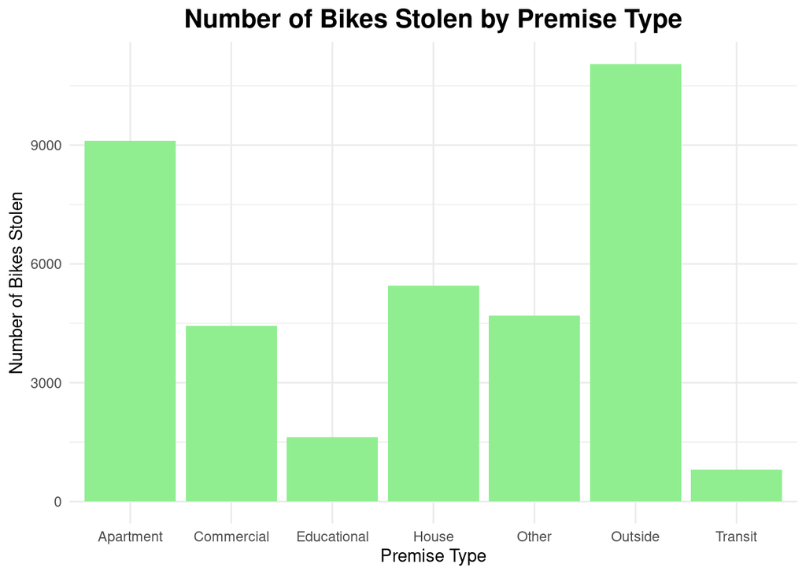

[interactive chart not shown]

Similarly, the Toronto heatmap shows theft occurrence by geographical location, displaying the theft density across Toronto with areas with a color spectrum starting from red, indicating high-density theft zones, to blue, indicating low density. The map highlights downtown Toronto as a significantly vulnerable area due to its concentrated bike theft cases. The high density of parked bicycles outdoors and inside the numerous condos could serve as the reason for the prevalence of bike thieves.

## When Are Bikes at Risk? Seasonal and Weekly Patterns in Theft

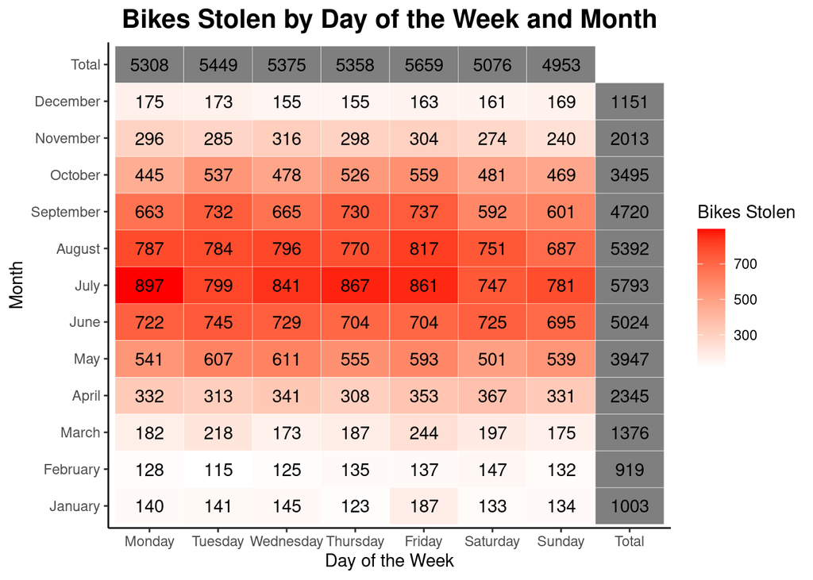

This heatmap shows the distribution of bike thefts across days of the week by month of the year. Each cell represents the number of thefts from the dataset and is colored based on this count. A darker shade of red in a cell indicates more thefts on this day of this month, and a lighter shade vice versa.

## What Bikes Do Thieves Target? Insights by Type and Value

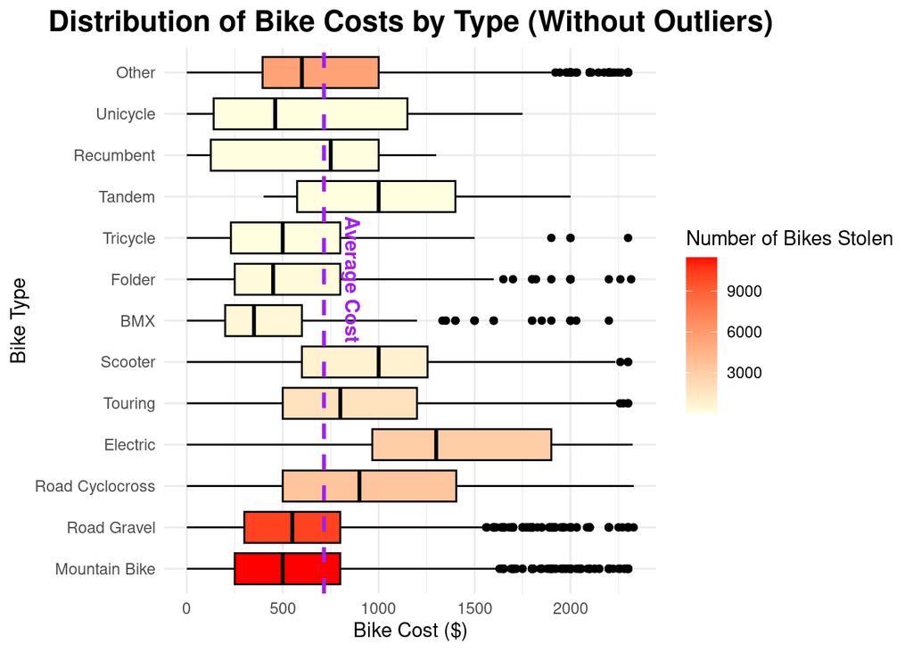

With the vulnerable locations and the days and months in mind, cyclists with certain types of bikes may also need to be aware. The above is a box plot that demonstrates the distribution of the costs of all stolen bikes for different bike types with number of thefts also shown by color. It highlights the bikes that are more likely to be stolen and their typical price range to help bikers make informed decisions based on their financial situation.

From the chart, of particular interest were Mountain bikes and Road Gravel bikes, which appear most frequently in theft reports. However, their median costs are both below the average cost for all types, meaning a loss of these bikes is unfortunate yet suffer less financially compared to other bike types. Conversely, Electric bikes and Road Cyclocross have a relatively high occurrence of thefts as well as higher than average costs. The owners of these bike types should be more aware to protect their assets because their bicycles are more appealing to thieves, and they could suffer more money loss if their loved bikes are stolen.

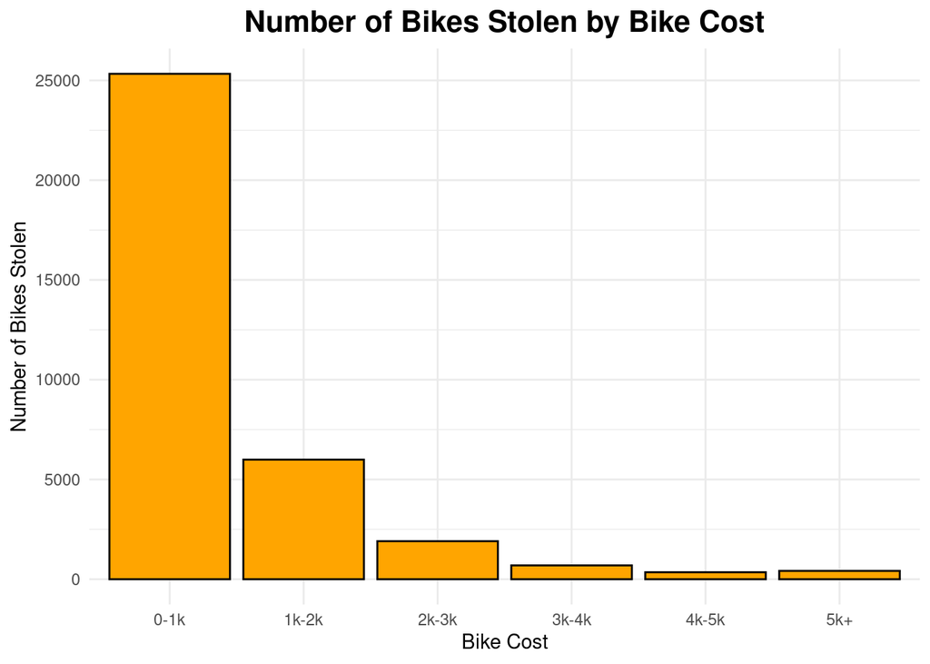

## Stand Out or Blend In: How Bike Color Impacts Risk of Loss

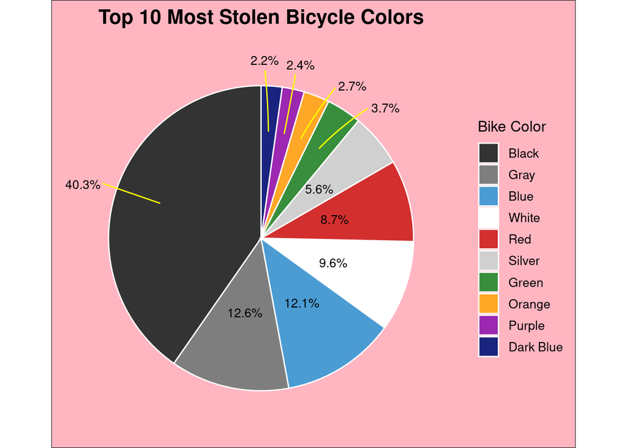

As a result, cyclists who wish to avoid bike theft may consider choosing less common or more distinguishable colors to make their bikes stand out, which may discourage stealing. From another perspective, having customized designs or using unique stickers on the bikes would make them less attractive to thieves as they would become much more recognizable, increasing the risk of theft activity.

## Towards a Safer Toronto: What are the Next Steps?

The analysis of Toronto’s bicycle theft patterns presented in this article provides a cohesive guide to assist cyclists in making safer choices and minimizing theft risks on their valuable bicycles. Through the understanding of where and when thefts are the most frequent, as well as which bike types and colors are more likely to be stolen, the biking community can adopt a proactive approach to securing their bikes. To summarize, areas with high reported cases of theft, such as outdoors and inside downtown apartments, suggest an urgent need for increased security in these locations. Moreover, seasonal and weekly patterns also reveal that extra vigilance should be paid during summer months and on workdays when unattended bikes are at greater risk.

It is essential for the Toronto Cycle Association to leverage these insights to promote enhanced security measures and advocate for improved bike storage solutions. Cyclists are encouraged to utilize our findings, including the vulnerability of Mountain bikes and Electric bikes as well as darker-colored bikes under risk of stealing, to make informed decisions on parking locations, bike type selection, and security measures. With these understandings in mind, we can increase community awareness and contribute to a more bicycle-friendly environment. By working together, we believe Toronto’s cycling community can reduce theft incidents and restore public trust in shared spaces.